# Meta-analysis

Ana BVA

14 luglio 2020

## Introduction

**Aim:** To perform a Meta-analysis using a random effect model

### Background

Some relevant information with links [GEO](https://www.ncbi.nlm.nih.gov/geo/)

## Input

This script needs the following files:

**Dataframe:** Matrix of differential gene expression analysis

## Analysis

### Setup

All the data has already been downloaded in the cluster *10.200.0.42*, for accessing:

```bash
ssh ana@10.200.0.42

cd /home/ana/R-projects/Meta-analysis_COPD
```

For running the script, type:

```bash
nohup R -e "rmarkdown::render('vignettes/Meta-analysis_Lung_Rawdata_9-July-2020.Rmd')" & > meta-analysis.out
```

The script can be found in: /home/ana/R-projects/Meta-analysis_COPD/vignettes

```r
setwd("..")
PATH = getwd()
DATA_DIR = file.path(PATH,"data")
OUTPUT_DIR = file.path(PATH,"output_data")
FIG_DIR = file.path(PATH,"fig")
TODAY = Sys.Date()

knitr::opts_knit$set(root.dir = PATH)
```

And this analysis is run in: /home/ana/R-projects/Meta-analysis_COPD

### Libraries

```r
library(tidyverse)
library(knitr)
library(ComplexHeatmap)
library(metafor)
library(pheatmap)
library(RColorBrewer)
```

### Experiments

We selected 7 experiments that are in PulmonDB and are lung samples from COPD patients and that also have a control group to compare. These experiments are described in the following table:

```r
gse_table <- read.csv(file.path(DATA_DIR,"GSE_table.csv"), row.names = 1)
kable(gse_table, caption = "GSE information")
```

GSE information

|  | Samples | Platform | Platform.manufacturer | Year | Category |
| --- | --- | --- | --- | --- | --- |
| GSE1122 | 15 | [Hu6800] | Affymetrix | 2004 | Normal lung & Emphysema & AAD |
| GSE1650 | 30 | [HG-U133A] | Affymetrix | 2004 | Normal or mild Emphysema & severe Emphysema |
| GSE27597 | 72 | [HuEx-1_0-st] | Affymetrix | 2011 | Normal lung & COPD and Emphysema |
| GSE37768 | 38 | [HG-U133_Plus_2] | Affymetrix | 2016 | Normal lung & COPD |
| GSE47460 | 582 | Agilent-014850 | Agilent | 2013 | Normal lung & COPD & ILD |
| GSE57148 | 189 | Illumina HiSeq 2000 | Illumina | 2015 | Normal lung & COPD |
| GSE8581 | 58 | [HG-U133_Plus_2] | Affymetrix | 2008 | Normal lung & COPD |

### STEP 1

We will import DE results from all experiments.

```r
full_tables <- read_csv(str_c(OUTPUT_DIR,"/Full_Tables_2020-07-13.csv"))
colnames(full_tables)
```

```
##  [1] "Gene.Symbol"             "logFC_GSE1122"
##  [3] "adj.P.Val_GSE1122"       "CI.L_GSE1122"
##  [5] "CI.R_GSE1122"            "logFC_GSE1650"
##  [7] "adj.P.Val_GSE1650"       "CI.L_GSE1650"
##  [9] "CI.R_GSE1650"            "logFC_GSE27597"
## [11] "adj.P.Val_GSE27597"      "CI.L_GSE27597"
## [13] "CI.R_GSE27597"           "logFC_GSE37768"
## [15] "adj.P.Val_GSE37768"      "CI.L_GSE37768"
## [17] "CI.R_GSE37768"           "logFC_GSE47460"
## [19] "adj.P.Val_GSE47460"      "CI.L_GSE47460"
## [21] "CI.R_GSE47460"           "log2FoldChange_GSE57148"
## [23] "padj_GSE57148"           "CI.L_GSE57148"
## [25] "CI.R_GSE57148"           "logFC_GSE8581"
## [27] "adj.P.Val_GSE8581"       "CI.L_GSE8581"
## [29] "CI.R_GSE8581"
```

```r
colnames(full_tables)[colnames(full_tables) == 'log2FoldChange_GSE57148'] <- 'logFC_GSE57148'
full_tables
```

```
## # A tibble: 35,275 x 29
##    Gene.Symbol logFC_GSE1122 adj.P.Val_GSE11… CI.L_GSE1122 CI.R_GSE1122
##    <chr>               <dbl>            <dbl>        <dbl>        <dbl>
##  1 ACVRL1             -1.47           0.00831       -1.87        -1.07
##  2 EVI2A               0.769          0.00975        0.543        0.996
##  3 USP13              -0.905          0.00975       -1.18        -0.629
##  4 ABCD3              -0.635          0.0117        -0.838       -0.432
##  5 TYMS                0.935          0.0117         0.633        1.24
##  6 SLC25A4            -0.655          0.0131        -0.875       -0.436
##  7 NUCB1               0.506          0.0131         0.336        0.677
##  8 AKAP1              -0.783          0.0179        -1.06        -0.509
##  9 PSMC1              -0.801          0.0186        -1.09        -0.517
## 10 KIF14               0.561          0.0218         0.352        0.770
## # … with 35,265 more rows, and 24 more variables: logFC_GSE1650 <dbl>,
## #   adj.P.Val_GSE1650 <dbl>, CI.L_GSE1650 <dbl>, CI.R_GSE1650 <dbl>,
## #   logFC_GSE27597 <dbl>, adj.P.Val_GSE27597 <dbl>, CI.L_GSE27597 <dbl>,
## #   CI.R_GSE27597 <dbl>, logFC_GSE37768 <dbl>, adj.P.Val_GSE37768 <dbl>,
## #   CI.L_GSE37768 <dbl>, CI.R_GSE37768 <dbl>, logFC_GSE47460 <dbl>,
## #   adj.P.Val_GSE47460 <dbl>, CI.L_GSE47460 <dbl>, CI.R_GSE47460 <dbl>,
## #   logFC_GSE57148 <dbl>, padj_GSE57148 <dbl>, CI.L_GSE57148 <dbl>,
## #   CI.R_GSE57148 <dbl>, logFC_GSE8581 <dbl>, adj.P.Val_GSE8581 <dbl>,
## #   CI.L_GSE8581 <dbl>, CI.R_GSE8581 <dbl>
```

### STEP 2

We first check pvalues histograms.

```r
FC <- str_subset(colnames(full_tables),"logFC")

# Genes with a adjusted p value


adjp <- full_tables %>%
  filter(Gene.Symbol != "NA") %>%
  gather("GSE"  ,"adjP",-Gene.Symbol) %>%
  filter(GSE %in% str_subset(colnames(full_tables),"adj.P.Val|padj")) %>%
  mutate(GSE=gsub(".*_","",GSE))

adjp
```

```
## # A tibble: 246,918 x 3
##    Gene.Symbol GSE        adjP
##    <chr>       <chr>     <dbl>
##  1 ACVRL1      GSE1122 0.00831
##  2 EVI2A       GSE1122 0.00975
##  3 USP13       GSE1122 0.00975
##  4 ABCD3       GSE1122 0.0117
##  5 TYMS        GSE1122 0.0117
##  6 SLC25A4     GSE1122 0.0131
##  7 NUCB1       GSE1122 0.0131
##  8 AKAP1       GSE1122 0.0179
##  9 PSMC1       GSE1122 0.0186
## 10 KIF14       GSE1122 0.0218
## # … with 246,908 more rows
```

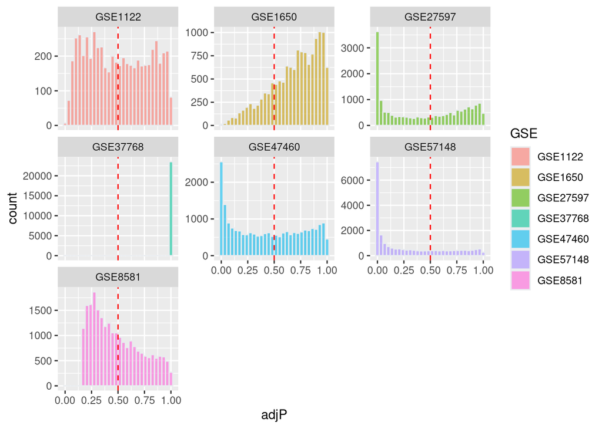

```r
#pdf("Pvalues.pdf",width = 8,height = 6)
adjp %>%
  group_by(GSE) %>%
  ggplot( aes(x=adjP, fill=GSE)) +
  geom_histogram( color="#e9ecef", alpha=0.6) + #position = 'identity'
  geom_vline(xintercept=0.5, linetype="dashed", color = "red") +
  facet_wrap(~GSE, scales = "free_y")
```

```r
#dev.off()

adj_pvalue <- 0.5
adjp <- filter(adjp,adjP < adj_pvalue)
adjp
```

```
## # A tibble: 56,711 x 3
##    Gene.Symbol GSE        adjP
##    <chr>       <chr>     <dbl>
##  1 ACVRL1      GSE1122 0.00831
##  2 EVI2A       GSE1122 0.00975
##  3 USP13       GSE1122 0.00975
##  4 ABCD3       GSE1122 0.0117
##  5 TYMS        GSE1122 0.0117
##  6 SLC25A4     GSE1122 0.0131
##  7 NUCB1       GSE1122 0.0131
##  8 AKAP1       GSE1122 0.0179
##  9 PSMC1       GSE1122 0.0186
## 10 KIF14       GSE1122 0.0218
## # … with 56,701 more rows
```

```r
# log fold change
logFC <- full_tables %>%
  filter(Gene.Symbol != "NA") %>%
  gather("GSE"  ,"logFC",-Gene.Symbol) %>%
  filter(GSE %in% str_subset(colnames(full_tables),"logFC")) %>%
  mutate(GSE=gsub(".*_","",GSE))

logFC
```

```
## # A tibble: 246,918 x 3
##    Gene.Symbol GSE      logFC
##    <chr>       <chr>    <dbl>
##  1 ACVRL1      GSE1122 -1.47
##  2 EVI2A       GSE1122  0.769
##  3 USP13       GSE1122 -0.905
##  4 ABCD3       GSE1122 -0.635
##  5 TYMS        GSE1122  0.935
##  6 SLC25A4     GSE1122 -0.655
##  7 NUCB1       GSE1122  0.506
##  8 AKAP1       GSE1122 -0.783
##  9 PSMC1       GSE1122 -0.801
## 10 KIF14       GSE1122  0.561
## # … with 246,908 more rows
```

```r
# recovering logFC values from genes with p value less than 0.01

ap0.01 <- left_join(adjp,logFC,by = c("Gene.Symbol" = "Gene.Symbol", "GSE" = "GSE")) %>%
  select(-adjP) %>%
  spread(GSE,logFC) %>%
  replace(is.na(.), 0)

ap0.01
```

```
## # A tibble: 26,380 x 7
##    Gene.Symbol GSE1122 GSE1650 GSE27597 GSE47460 GSE57148 GSE8581
##    <chr>         <dbl>   <dbl>    <dbl>    <dbl>    <dbl>   <dbl>
##  1 A1BG              0   0       0.0915   0        -0.173  0
##  2 A1BG-AS1          0   0       0        0        -0.226  0
##  3 A1CF              0   0       0        0         0      0.221
##  4 A2LD1             0   0       0.0893   0         0      0
##  5 A2M               0   0.356   0.130   -0.0827    0.181 -0.117
##  6 A2M-AS1           0   0       0        0        -0.937 -0.387
##  7 A2ML1             0   0       0       -0.105     0     -0.0871
##  8 A2MP1             0   0       0        0         0      0.280
##  9 A3GALT2           0   0       0        0         0.536  0
## 10 A4GALT            0   0      -0.322    0.372     0      0
## # … with 26,370 more rows
```

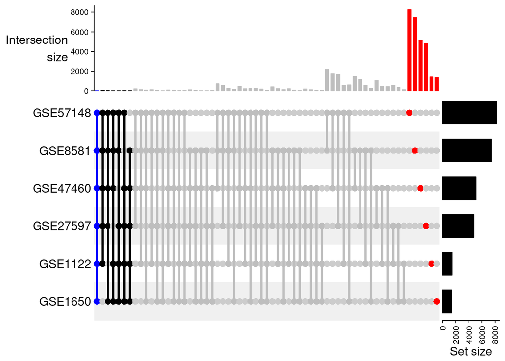

```r
# selecting up regulated genes
up <- ap0.01 %>%
  mutate_at(vars(-Gene.Symbol),funs(if_else( .>0, 1, 0)))
down <- ap0.01 %>%
  mutate_at(vars(-Gene.Symbol),funs(if_else( .<0, 1, 0)))

### UP
m <- make_comb_mat(up,mode = "intersect")
m <- m[comb_degree(m) >= 1]

#pdf("upsetUP.pdf",width = 14,height = 6)
UpSet(m,
      pt_size = unit(3, "mm"),
      lwd = 3,
      comb_col = c("red", "grey","grey","grey", "black","blue")[comb_degree(m)]
      #order.by = "freq"
    )
```

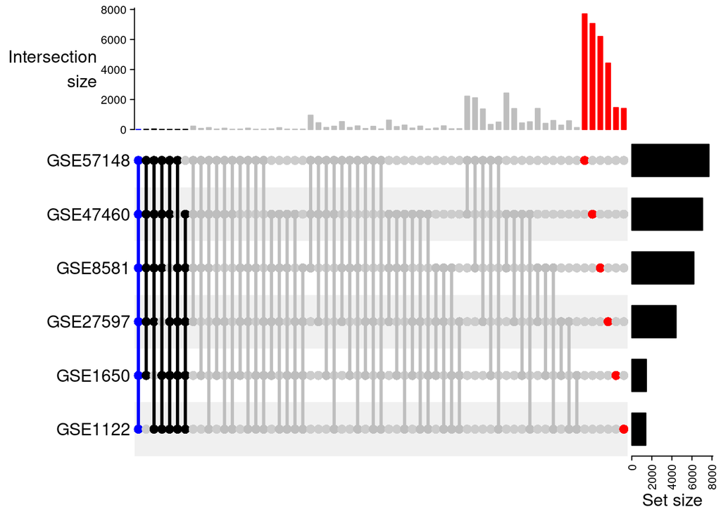

```r
#dev.off()


### DOWN
m <- make_comb_mat(down,mode = "intersect")
m <- m[comb_degree(m) >= 1]

#pdf("upsetDOWN.pdf",width = 14,height = 6)
UpSet(m,
      pt_size = unit(3, "mm"),
      lwd = 3,
      comb_col = c("red", "grey","grey","grey", "black","blue")[comb_degree(m)]
      #order.by = "freq"
    )
```

```r
#dev.off()
```

## Meta-analysis

We first calculate the Standar error using confidence intervals

```r
CI.R <- str_subset(colnames(full_tables),"CI.R")
CI.L <- str_subset(colnames(full_tables),"CI.L")

for(i in 1:length(CI.R)) {
  full_tables[str_c("SE_",gsub(".*_","",CI.R))] <- (full_tables[,CI.R]-full_tables[,CI.L]) /(2*1.96)
}
```

Meta-analysis for a single gene

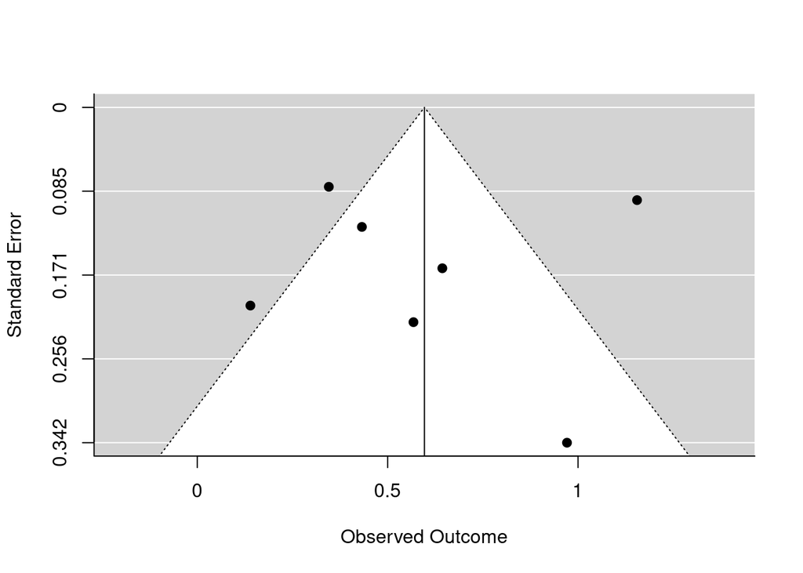

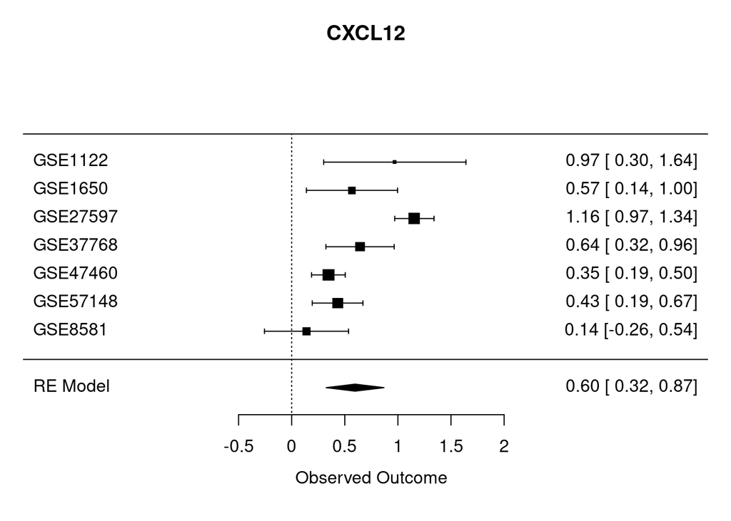

```r
FC <- str_subset(colnames(full_tables),"logFC")
SE <- str_subset(colnames(full_tables),"SE_")
GSE <- gsub(".*_","",FC)

gs <- "CXCL12"
meta.plot <- function(gs){
gene <-  na.omit(full_tables[full_tables$Gene.Symbol == gs,])

yi <- as.numeric(gene[,FC])
sei <- as.numeric(gene[,SE])

# meta analysis in the simplest way
res <- metafor::rma(yi, sei=sei)
funnel(res)
forest(res,slab = GSE, main=unique(gene$Gene.Symbol))
}

meta.plot(gs)
```

Meta-analysis for all genes

```r
gs <- unique(na.omit(full_tables)$Gene.Symbol)

meta <- data.frame(genes = 0,
                   QEp=0,
                   pval=0)


length(gs)
```

```
## [1] 4592
```

```r
for (i in 1:length(gs)) {
  gene <-  na.omit(full_tables[full_tables$Gene.Symbol == gs[i],])
  yi <- as.numeric(gene[,FC])
  sei <- as.numeric(gene[,SE])
  # meta analysis with random models "REML"
  res <- metafor::rma(yi, sei=sei)
  meta <- rbind(meta,c(gs[i],res$QEp,res$pval))
}
```

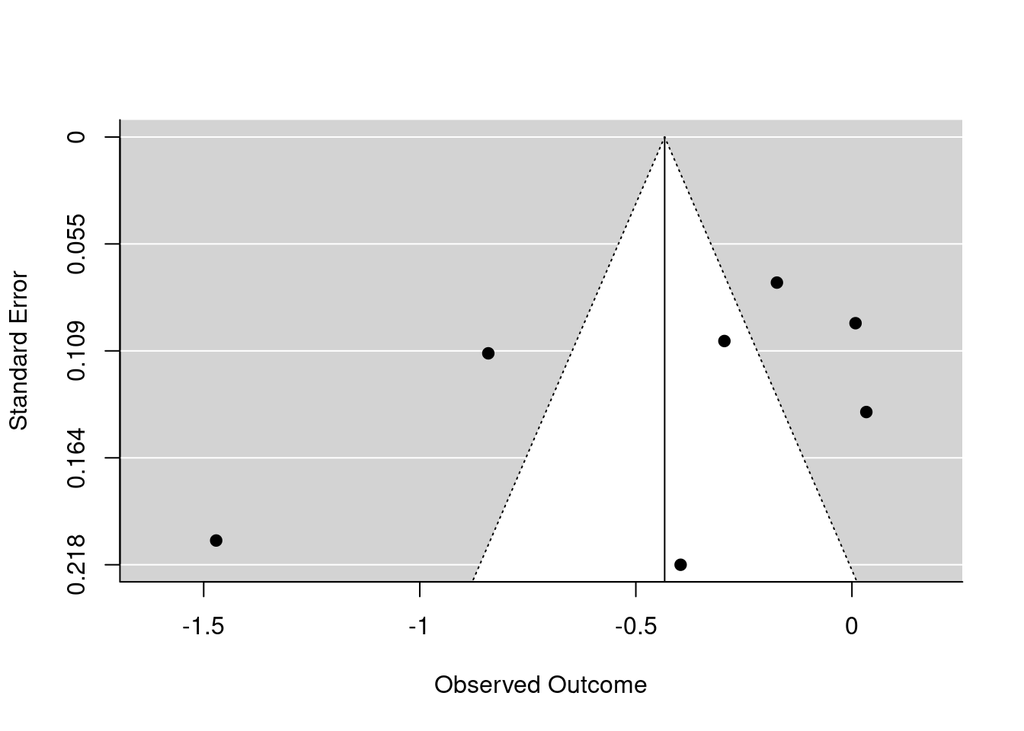

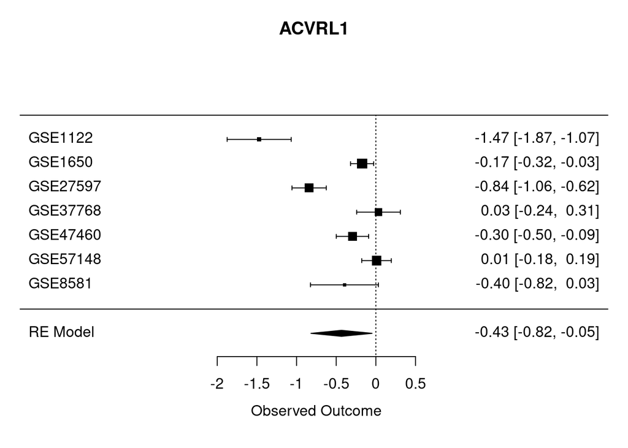

```r
meta <- meta[-1,]
meta$QEp <- as.numeric(meta$QEp)
meta$pval <- as.numeric(meta$pval)

# FDR correction
meta$qval <- p.adjust(meta$pval,method="fdr")

meta.plot(meta$genes[1])
```

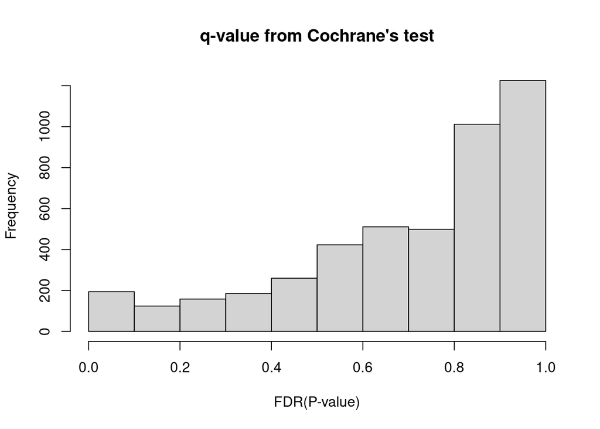

```r
hist(meta$qval, main="q-value from Cochrane's test", xlab="FDR(P-value)")
```

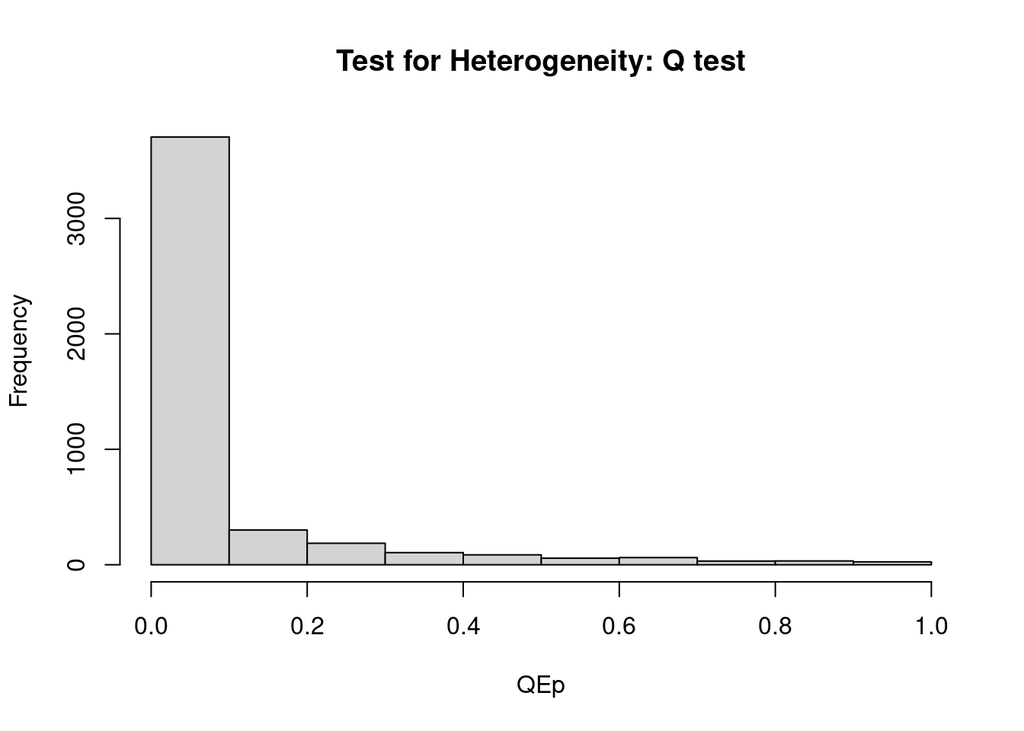

```r
hist(meta$QEp, main="Test for Heterogeneity: Q test", xlab="QEp")
```

```r
genesqval <- meta[meta$qval < 0.01,]
#genesqval <- genesqval[genesqval$QEp < 0.2,]
genesqval <-  genesqval[order(genesqval$qval),]

kable(genesqval, caption = "Meta-analysis")
```

Meta-analysis

|  | genes | QEp | pval | qval |
| --- | --- | --- | --- | --- |
| 3036 | GAS2L1 | 0.2664439 | 0.0000000 | 0.0000002 |
| 1268 | PTGS1 | 0.1512006 | 0.0000000 | 0.0000005 |
| 1317 | PDK1 | 0.4176125 | 0.0000000 | 0.0000005 |
| 3005 | CFI | 0.7507777 | 0.0000000 | 0.0000005 |
| 2542 | HPCAL1 | 0.4190431 | 0.0000000 | 0.0000006 |
| 771 | GNAI2 | 0.0904905 | 0.0000000 | 0.0000094 |
| 1744 | WIPF1 | 0.5673136 | 0.0000000 | 0.0000135 |
| 1779 | C7 | 0.2542412 | 0.0000000 | 0.0000208 |
| 968 | THY1 | 0.8189824 | 0.0000001 | 0.0000266 |
| 893 | TLE2 | 0.5172197 | 0.0000001 | 0.0000545 |
| 254 | COL14A1 | 0.0017973 | 0.0000002 | 0.0000669 |
| 763 | FOLR2 | 0.8880351 | 0.0000002 | 0.0000669 |
| 2149 | LOXL1 | 0.1415458 | 0.0000002 | 0.0000669 |
| 305 | ST6GAL1 | 0.2579679 | 0.0000003 | 0.0000792 |
| 1672 | GALNT1 | 0.0957123 | 0.0000003 | 0.0000792 |
| 517 | CD69 | 0.7133268 | 0.0000003 | 0.0000810 |
| 1256 | GPNMB | 0.2864809 | 0.0000004 | 0.0001092 |
| 3543 | UBE2L3 | 0.1428596 | 0.0000004 | 0.0001092 |
| 4133 | RARRES1 | 0.9015064 | 0.0000005 | 0.0001092 |
| 204 | PDAP1 | 0.1940309 | 0.0000006 | 0.0001302 |
| 2070 | CA4 | 0.7271771 | 0.0000010 | 0.0002091 |
| 1669 | TBX5 | 0.9469533 | 0.0000012 | 0.0002422 |
| 3440 | HYAL1 | 0.5162892 | 0.0000013 | 0.0002552 |
| 142 | CTSS | 0.3092156 | 0.0000021 | 0.0004058 |
| 419 | ATF4 | 0.1096536 | 0.0000024 | 0.0004430 |
| 2652 | GMPR | 0.9496470 | 0.0000040 | 0.0007061 |
| 604 | UBL4A | 0.1951332 | 0.0000048 | 0.0008242 |
| 265 | AKR1C3 | 0.2229690 | 0.0000057 | 0.0009412 |
| 2700 | CBLN1 | 0.2585606 | 0.0000070 | 0.0010298 |
| 3004 | RAE1 | 0.3917680 | 0.0000069 | 0.0010298 |
| 4023 | GLIPR1 | 0.2693800 | 0.0000066 | 0.0010298 |
| 2478 | SGSH | 0.8365519 | 0.0000077 | 0.0011062 |
| 2656 | HSF1 | 0.4158157 | 0.0000101 | 0.0014110 |
| 3194 | MITF | 0.1386389 | 0.0000123 | 0.0016134 |
| 4009 | SLC16A2 | 0.3800093 | 0.0000123 | 0.0016134 |
| 310 | CCL13 | 0.1450834 | 0.0000134 | 0.0017151 |
| 3828 | ZNF75D | 0.2221378 | 0.0000146 | 0.0018082 |
| 2833 | AEBP1 | 0.0818533 | 0.0000160 | 0.0019347 |
| 730 | TESK1 | 0.5068557 | 0.0000168 | 0.0019750 |
| 354 | CXCL12 | 0.0000000 | 0.0000179 | 0.0019952 |
| 797 | CDH11 | 0.0008153 | 0.0000175 | 0.0019952 |
| 2152 | GTF3C2 | 0.2691992 | 0.0000187 | 0.0019952 |
| 3022 | PTGER4 | 0.0228418 | 0.0000186 | 0.0019952 |
| 1743 | ARPC1A | 0.2785180 | 0.0000208 | 0.0021720 |
| 916 | PPP4C | 0.1682681 | 0.0000265 | 0.0026420 |
| 2803 | ICAM3 | 0.5605211 | 0.0000262 | 0.0026420 |
| 1805 | ANXA3 | 0.2497443 | 0.0000344 | 0.0033607 |
| 2564 | COL10A1 | 0.0014926 | 0.0000359 | 0.0034311 |
| 3980 | ACADVL | 0.3438849 | 0.0000370 | 0.0034689 |
| 61 | ARF6 | 0.0366741 | 0.0000427 | 0.0039247 |
| 7 | SLC25A4 | 0.0013167 | 0.0000576 | 0.0051845 |
| 468 | IGFBP6 | 0.1905290 | 0.0000758 | 0.0066670 |
| 2755 | MFAP2 | 0.0290345 | 0.0000769 | 0.0066670 |
| 3761 | CCND2 | 0.1223586 | 0.0000867 | 0.0073750 |
| 1700 | CDH3 | 0.6716863 | 0.0000884 | 0.0073784 |
| 3349 | SLC39A6 | 0.0402144 | 0.0000913 | 0.0074862 |
| 527 | PPP2CB | 0.2622764 | 0.0000947 | 0.0076324 |
| 1900 | SLC5A3 | 0.0058647 | 0.0001045 | 0.0082747 |
| 774 | POLRMT | 0.0193068 | 0.0001069 | 0.0083105 |
| 1840 | PPP5C | 0.1188311 | 0.0001086 | 0.0083105 |
| 667 | INPP5D | 0.2361615 | 0.0001136 | 0.0084145 |
| 1465 | ZNF7 | 0.1147400 | 0.0001126 | 0.0084145 |
| 315 | FRZB | 0.0000000 | 0.0001187 | 0.0085936 |
| 2619 | FAP | 0.0427207 | 0.0001198 | 0.0085936 |
| 1555 | CCL11 | 0.4037918 | 0.0001221 | 0.0086262 |
| 40 | ALPP | 0.1661665 | 0.0001332 | 0.0092671 |
| 2086 | VIPR1 | 0.3903366 | 0.0001374 | 0.0094199 |
| 643 | SLC28A1 | 0.5728193 | 0.0001395 | 0.0094203 |
| 3588 | NPAT | 0.2602586 | 0.0001434 | 0.0095418 |
| 3298 | NCOA2 | 0.1785161 | 0.0001509 | 0.0098964 |

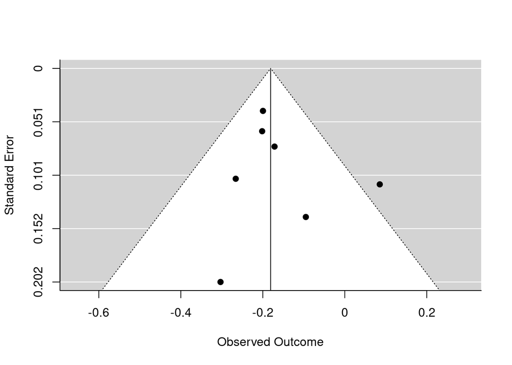

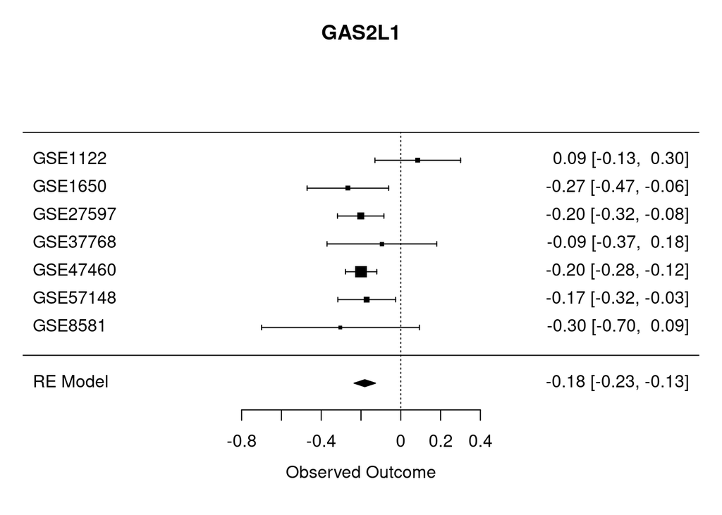

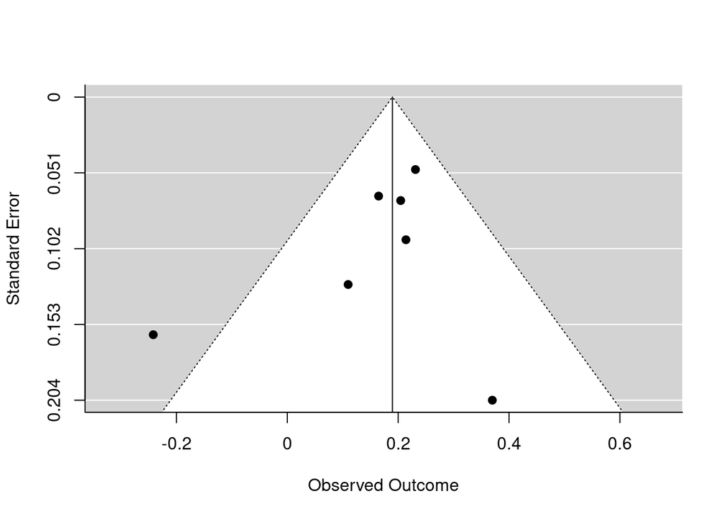

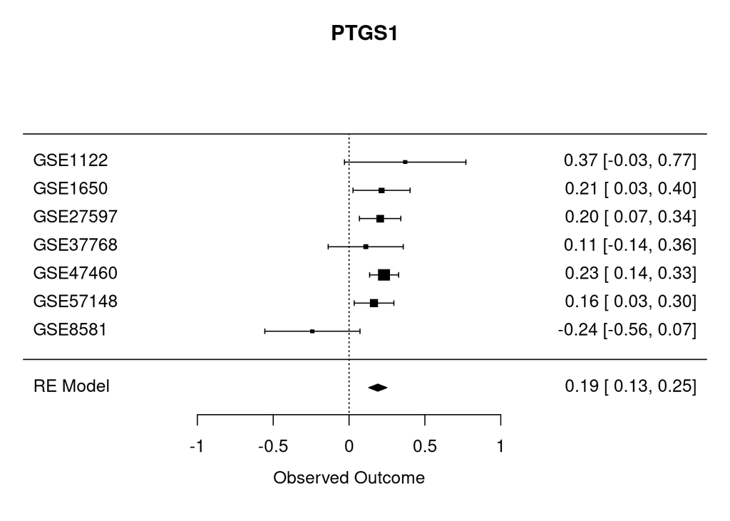

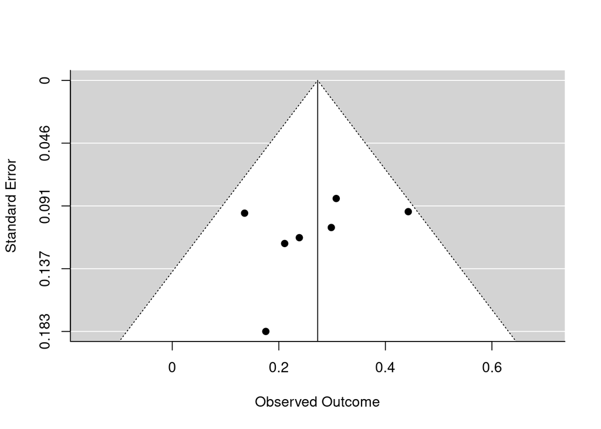

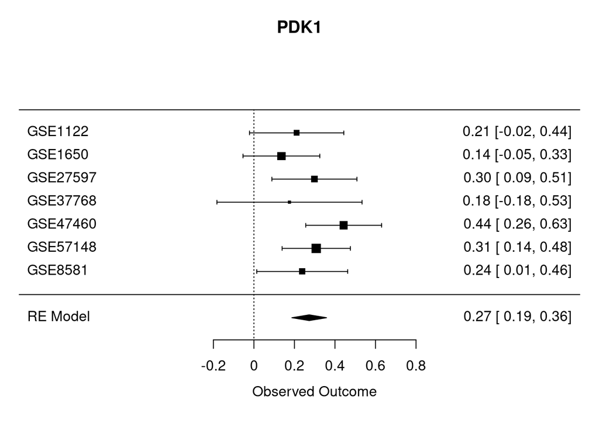

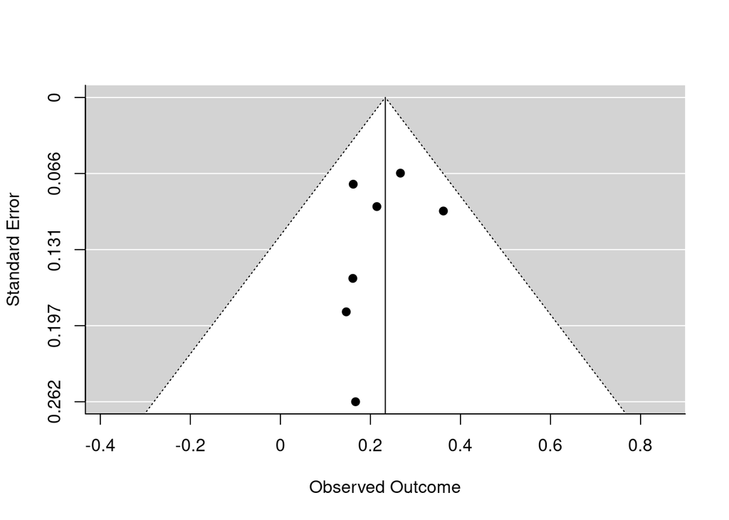

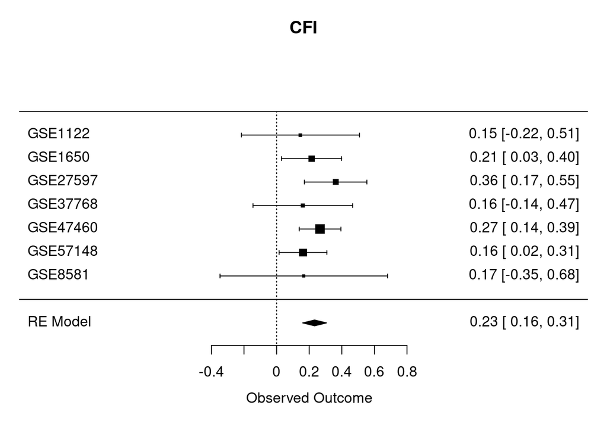

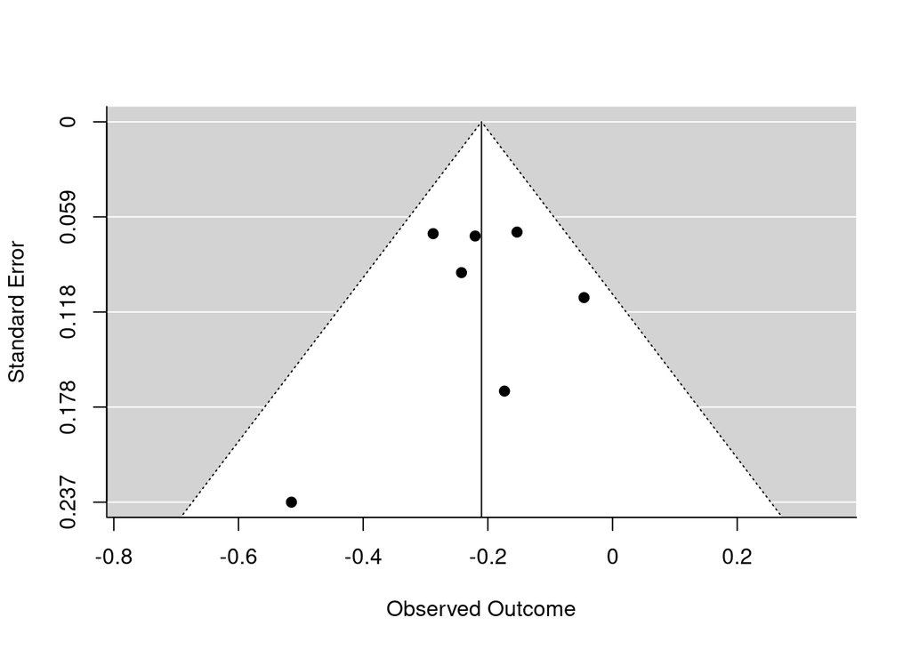

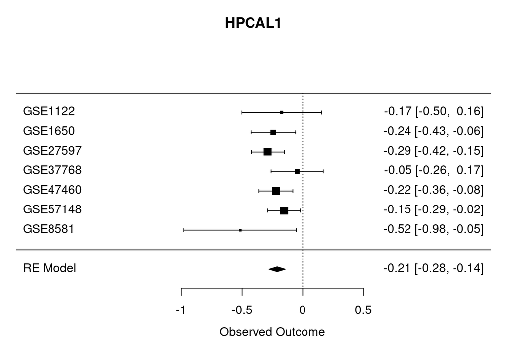

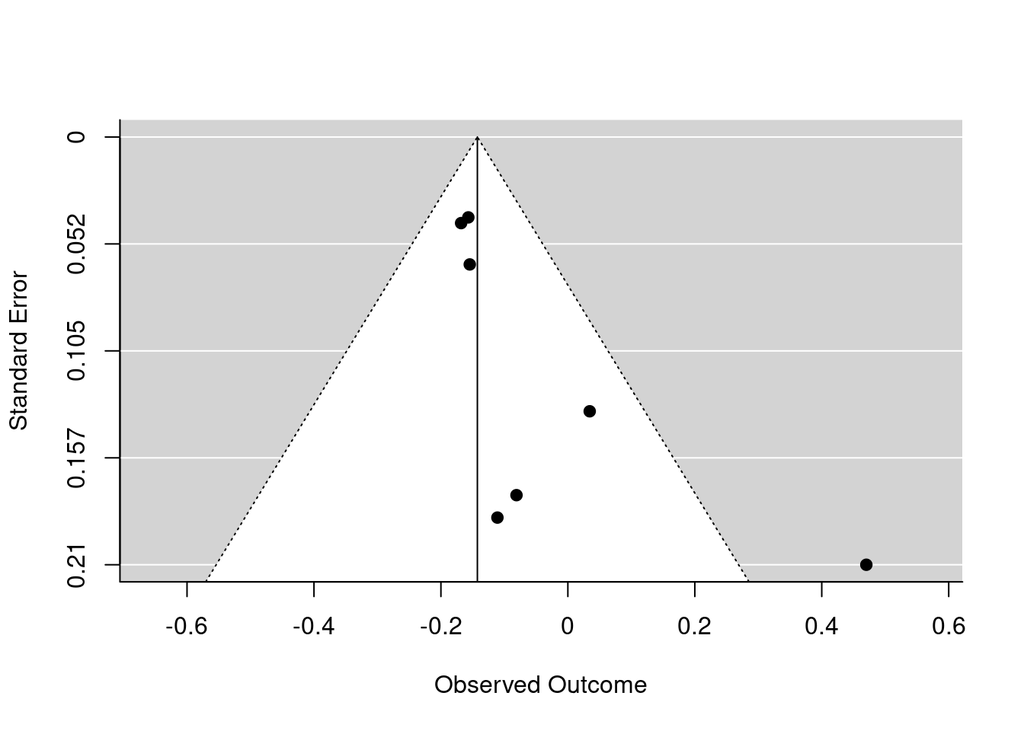

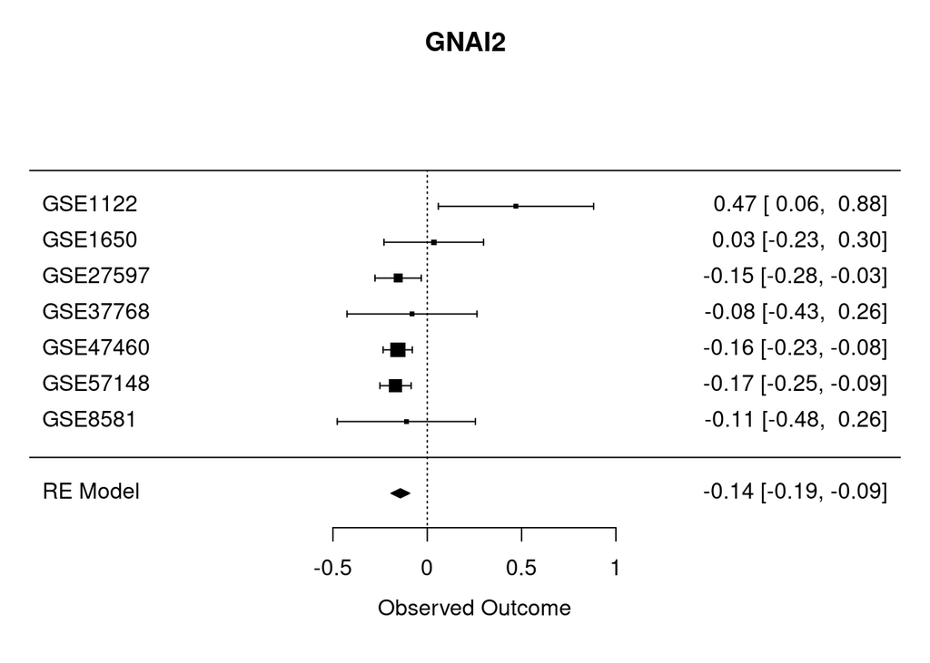

[18 more figures not shown]

```r
for (i in 1:15){
meta.plot(genesqval$genes[i])
}
```

```r
color <- colorRampPalette(brewer.pal(n = 9, name = "RdBu"))(15) #"BrBG"
topgenes <- full_tables[full_tables$Gene.Symbol %in% genesqval$genes,FC]
rownames(topgenes) <- genesqval$genes
```

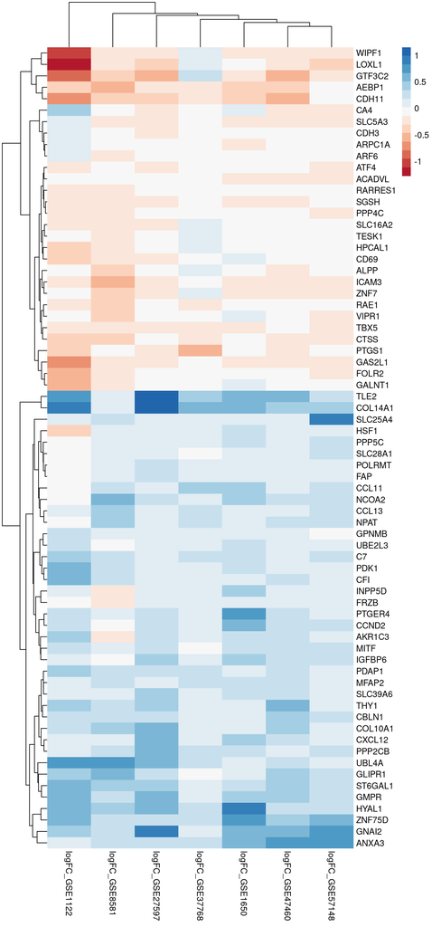

```r
pheatmap(topgenes,
         color = color,
         fontsize = 10,
         cluster_cols = T,
         show_colnames = T,
         border_color = NA)
```